# Final Project - Kaggle Competition (Titanic)

## 1) Preprocessing & EDA

My first step is to import all standard packages:

```python
import numpy as np
import matplotlib.pyplot as plt
import pandas as pd
import os as os
import glob
import time
from operator import itemgetter
```

SKLearn packages I know I'll likely need:

```python
from sklearn import preprocessing
from sklearn.model_selection  import train_test_split, cross_val_score, KFold
from sklearn.model_selection import GridSearchCV
from sklearn.metrics import accuracy_score, precision_score, recall_score, f1_score
from sklearn.metrics import roc_curve, auc, confusion_matrix, classification_report, r2_score, mean_squared_error,mean_absolute_error
```

Setting my directory:

```python
cd /Users/Tyler/Desktop/Katie/Predictive Models (Spring B 2019)/Titanic/
```

```
C:\Users\Tyler\Desktop\Katie\Predictive Models (Spring B 2019)\Titanic
```

```python
from chardet.universaldetector import UniversalDetector
usock = open('combined_titanic.csv', 'rb')
detector = UniversalDetector()
for line in usock.readlines():
    detector.feed(line)
    if detector.done: break
detector.close()
usock.close()
print (detector.result)
```

```
{'encoding': 'ascii', 'confidence': 1.0, 'language': ''}
```

There were originally two csv files created for this data; test_titanic and train_titanic. I manually combined these into one csv for the purpose of my code, as I want to randomize the data for honest results when I create my own training/test sets in Python:

```python
Titanic=pd.read_csv("combined_titanic.csv", encoding="ascii")
Titanic.shape
```

```
(1309, 12)
```

```python
Titanic.dtypes
```

```
PassengerId      int64
Survived       float64
Pclass           int64
Name            object
Sex             object
Age            float64
SibSp            int64
Parch            int64
Ticket          object
Fare           float64
Cabin           object
Embarked        object
dtype: object
```

Now that I've combined my csv files and renamed my main dataframe to 'Titanic' for simplicity's sake, I want to set my target variable before I do any more preprocessing:

```python
targetName = 'Survived'
targetSeries = Titanic[targetName]

del Titanic[targetName]
Titanic.insert(0, targetName, targetSeries)

Titanic.tail(5)
```

|  | Survived | PassengerId | Pclass | Name | Sex | Age | SibSp | Parch | Ticket | Fare | Cabin | Embarked |
| --- | --- | --- | --- | --- | --- | --- | --- | --- | --- | --- | --- | --- |
| 1304 | NaN | 1305 | 3 | Spector, Mr. Woolf | male | NaN | 0 | 0 | A.5. 3236 | 8.0500 | NaN | S |
| 1305 | NaN | 1306 | 1 | Oliva y Ocana, Dona. Fermina | female | 39.0 | 0 | 0 | PC 17758 | 108.9000 | C105 | C |
| 1306 | NaN | 1307 | 3 | Saether, Mr. Simon Sivertsen | male | 38.5 | 0 | 0 | SOTON/O.Q. 3101262 | 7.2500 | NaN | S |
| 1307 | NaN | 1308 | 3 | Ware, Mr. Frederick | male | NaN | 0 | 0 | 359309 | 8.0500 | NaN | S |
| 1308 | NaN | 1309 | 3 | Peter, Master. Michael J | male | NaN | 1 | 1 | 2668 | 22.3583 | NaN | C |

Before I manipulate any further, I'm going to use PassengerID against some other features to see if I can get a quick look at any NA values in the data I'll need to change later

```python
Titanic.isnull().sum()
```

```
Survived        418
PassengerId       0
Pclass            0
Name              0
Sex               0
Age             263
SibSp             0
Parch             0
Ticket            0
Fare              1
Cabin          1014
Embarked          2
dtype: int64
```

```python
round(418/len(Titanic["PassengerId"]),4) ## Around 32% of my target variable doesn't have a yes/no answer
```

```
0.3193
```

```python
round(263/len(Titanic["PassengerId"]),4) ## Around 20% of the Age feature is null
```

```
0.2009
```

```python
round(2/len(Titanic["PassengerId"]),4) ## Not many of my Embarked values are missing
```

```
0.0015
```

```python
round(1/len(Titanic["PassengerId"]),4) ## Same goes for Fare
```

```
0.0008
```

The EDA above allows me to make a decision not only on which features I'll alter with 'fillna' later, but it also ties into my decision-making with feature selection

Feature selection to remove 'ID' type columns:

```python
del Titanic['Name']
del Titanic['PassengerId']
del Titanic['Ticket']
del Titanic['Cabin']

Titanic.columns
```

```
Index(['Survived', 'Pclass', 'Sex', 'Age', 'SibSp', 'Parch', 'Fare',
       'Embarked'],
      dtype='object')
```

#### Quick EDA:

```python
pd.set_option('display.max_rows', 10000)
pd.set_option('display.max_columns', 10000)
```

```python
Titanic.groupby('Embarked').size()
```

```
Embarked
C    270
Q    123
S    914
dtype: int64
```

```python
Titanic.groupby('Sex').size()
```

```
Sex
female    466
male      843
dtype: int64
```

```python
Titanic["Survived"].describe() ## Based on mean alone, it appears it's more likely to die than survive
```

```
count    891.000000
mean       0.383838
std        0.486592
min        0.000000
25%        0.000000
50%        0.000000
75%        1.000000
max        1.000000
Name: Survived, dtype: float64
```

I want to further explore this low chance of survival, by bringing passenger class into the mix:

```python
Titanic.groupby('Pclass').mean() ## This confirms my suspicion that higher passenger class is correlated with survival
```

| Pclass | Survived | Age | SibSp | Parch | Fare |
| --- | --- | --- | --- | --- | --- |
| 1 | 0.629630 | 39.159930 | 0.436533 | 0.365325 | 87.508992 |
| 2 | 0.472826 | 29.506705 | 0.393502 | 0.368231 | 21.179196 |
| 3 | 0.242363 | 24.816367 | 0.568406 | 0.400564 | 13.302889 |

Same for gender:

```python
Titanic.groupby('Sex').mean() ## Another suspicion seems to be confirmed, with the ratio of men-women survival being highly unbalanced in women's favor even though there were more men on the ship overall
```

| Sex | Survived | Pclass | Age | SibSp | Parch | Fare |
| --- | --- | --- | --- | --- | --- | --- |
| female | 0.742038 | 2.154506 | 28.687088 | 0.652361 | 0.633047 | 46.198097 |
| male | 0.188908 | 2.372479 | 30.585228 | 0.413998 | 0.247924 | 26.154601 |

#### Pre-processing continued:

Another look at my dataframe after initial pre-processing:

```python
Titanic.dtypes ## Still left with two 'object' dtypes that will need to be dummied out
```

```
Survived    float64
Pclass        int64
Sex          object
Age         float64
SibSp         int64
Parch         int64
Fare        float64
Embarked     object
dtype: object
```

```python
Titanic.shape
```

```
(1309, 8)
```

Remove all NA values:

```python
import matplotlib.pyplot as plt
plt.rc("font", size=14)
import seaborn as sns
sns.set(style="white") #white background style for seaborn plots
sns.set(style="whitegrid", color_codes=True)
```

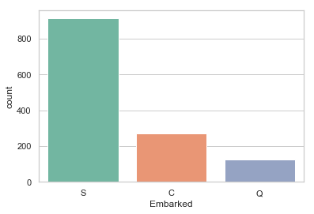

```python
sns.countplot(x='Embarked',data=Titanic,palette='Set2')
plt.show()
```

'S' was the most common port, so I'm going to fill all NA values with 'S' for Embark

```python
Titanic["Embarked"].fillna("S", inplace=True)
```

Now I'm going to explore all of the rest of my features

```python
Titanic["Age"].mean()
```

```
29.881137667304014
```

```python
Titanic["Age"].fillna(30, inplace=True)
```

```python
Titanic["Survived"].fillna(0, inplace=True)
```

```python
Titanic["Fare"].mean()
```

```
33.2954792813456
```

```python
Titanic["Fare"].fillna(33, inplace=True)
```

#### Regrouping & final pre-processing:

```python
Titanic.tail(10) ## I need to randomize my data, since the tailend of the df has NA values for the target variable
```

|  | Survived | Pclass | Sex | Age | SibSp | Parch | Fare | Embarked |
| --- | --- | --- | --- | --- | --- | --- | --- | --- |
| 1299 | 0.0 | 3 | female | 30.0 | 0 | 0 | 7.7208 | Q |
| 1300 | 0.0 | 3 | female | 3.0 | 1 | 1 | 13.7750 | S |
| 1301 | 0.0 | 3 | female | 30.0 | 0 | 0 | 7.7500 | Q |
| 1302 | 0.0 | 1 | female | 37.0 | 1 | 0 | 90.0000 | Q |
| 1303 | 0.0 | 3 | female | 28.0 | 0 | 0 | 7.7750 | S |
| 1304 | 0.0 | 3 | male | 30.0 | 0 | 0 | 8.0500 | S |
| 1305 | 0.0 | 1 | female | 39.0 | 0 | 0 | 108.9000 | C |
| 1306 | 0.0 | 3 | male | 38.5 | 0 | 0 | 7.2500 | S |
| 1307 | 0.0 | 3 | male | 30.0 | 0 | 0 | 8.0500 | S |
| 1308 | 0.0 | 3 | male | 30.0 | 1 | 1 | 22.3583 | C |

```python
Titanic.dtypes
```

```
Survived    float64
Pclass        int64
Sex          object
Age         float64
SibSp         int64
Parch         int64
Fare        float64
Embarked     object
dtype: object
```

It seems to me that there are two features, 'Parch' and 'SibSp', that essentially tell me the same thing - whether or not someone travelled alone. I want to combine these to avoid any collinearity:

```python
Titanic['travel_group']=Titanic["SibSp"]+Titanic["Parch"]
Titanic['travel_alone']=np.where(Titanic['travel_group']>0, 0, 1)
```

```python
Titanic.drop('SibSp', axis=1, inplace=True)
Titanic.drop('Parch', axis=1, inplace=True)
Titanic.drop('travel_group', axis=1, inplace=True)
```

Dummies for Categorial Variables (Sex, Pclass, & Embarked):

```python
Sex_dummy = pd.DataFrame(pd.get_dummies(Titanic['Sex']))
Titanic = Titanic.join(Sex_dummy)
Titanic.drop(["Sex"], axis = 1, inplace = True)

Sex_dummy.head(5)
```

|  | female | male |
| --- | --- | --- |
| 0 | 0 | 1 |
| 1 | 1 | 0 |
| 2 | 1 | 0 |
| 3 | 1 | 0 |
| 4 | 0 | 1 |

```python
Titanic.drop('female', axis=1, inplace=True)
```

```python
Embarked_dummy = pd.DataFrame(pd.get_dummies(Titanic['Embarked']))
Titanic = Titanic.join(Embarked_dummy)
Titanic.drop(["Embarked"], axis = 1, inplace = True)
Embarked_dummy.head(5)
```

|  | C | Q | S |
| --- | --- | --- | --- |
| 0 | 0 | 0 | 1 |
| 1 | 1 | 0 | 0 |
| 2 | 0 | 0 | 1 |
| 3 | 0 | 0 | 1 |
| 4 | 0 | 0 | 1 |

```python
Pclass_dummy = pd.DataFrame(pd.get_dummies(Titanic['Pclass']))
Titanic = Titanic.join(Pclass_dummy)
Titanic.drop(["Pclass"], axis = 1, inplace = True)
Pclass_dummy.head(5)
```

|  | 1 | 2 | 3 |
| --- | --- | --- | --- |
| 0 | 0 | 0 | 1 |
| 1 | 1 | 0 | 0 |
| 2 | 0 | 0 | 1 |
| 3 | 1 | 0 | 0 |
| 4 | 0 | 0 | 1 |

```python
Titanic.columns
```

```
Index(['Survived', 'Age', 'Fare', 'travel_alone', 'male', 'C', 'Q', 'S', 1, 2,
       3],
      dtype='object')
```

```python
Titanic.head(15)
```

|  | Survived | Age | Fare | travel_alone | male | C | Q | S | 1 | 2 | 3 |
| --- | --- | --- | --- | --- | --- | --- | --- | --- | --- | --- | --- |
| 0 | 0.0 | 22.0 | 7.2500 | 0 | 1 | 0 | 0 | 1 | 0 | 0 | 1 |
| 1 | 1.0 | 38.0 | 71.2833 | 0 | 0 | 1 | 0 | 0 | 1 | 0 | 0 |
| 2 | 1.0 | 26.0 | 7.9250 | 1 | 0 | 0 | 0 | 1 | 0 | 0 | 1 |
| 3 | 1.0 | 35.0 | 53.1000 | 0 | 0 | 0 | 0 | 1 | 1 | 0 | 0 |
| 4 | 0.0 | 35.0 | 8.0500 | 1 | 1 | 0 | 0 | 1 | 0 | 0 | 1 |
| 5 | 0.0 | 30.0 | 8.4583 | 1 | 1 | 0 | 1 | 0 | 0 | 0 | 1 |
| 6 | 0.0 | 54.0 | 51.8625 | 1 | 1 | 0 | 0 | 1 | 1 | 0 | 0 |
| 7 | 0.0 | 2.0 | 21.0750 | 0 | 1 | 0 | 0 | 1 | 0 | 0 | 1 |
| 8 | 1.0 | 27.0 | 11.1333 | 0 | 0 | 0 | 0 | 1 | 0 | 0 | 1 |
| 9 | 1.0 | 14.0 | 30.0708 | 0 | 0 | 1 | 0 | 0 | 0 | 1 | 0 |
| 10 | 1.0 | 4.0 | 16.7000 | 0 | 0 | 0 | 0 | 1 | 0 | 0 | 1 |
| 11 | 1.0 | 58.0 | 26.5500 | 1 | 0 | 0 | 0 | 1 | 1 | 0 | 0 |
| 12 | 0.0 | 20.0 | 8.0500 | 1 | 1 | 0 | 0 | 1 | 0 | 0 | 1 |
| 13 | 0.0 | 39.0 | 31.2750 | 0 | 1 | 0 | 0 | 1 | 0 | 0 | 1 |
| 14 | 0.0 | 14.0 | 7.8542 | 1 | 0 | 0 | 0 | 1 | 0 | 0 | 1 |

```python
Titanic.shape
```

```
(1309, 11)
```

Randomizing my observations:

```python
Titanic = Titanic.sample(frac=1)
```

```python
Titanic.tail(20)
```

|  | Survived | Age | Fare | travel_alone | male | C | Q | S | 1 | 2 | 3 |
| --- | --- | --- | --- | --- | --- | --- | --- | --- | --- | --- | --- |
| 157 | 0.0 | 30.0 | 8.0500 | 1 | 1 | 0 | 0 | 1 | 0 | 0 | 1 |
| 228 | 0.0 | 18.0 | 13.0000 | 1 | 1 | 0 | 0 | 1 | 0 | 1 | 0 |
| 309 | 1.0 | 30.0 | 56.9292 | 1 | 0 | 1 | 0 | 0 | 1 | 0 | 0 |
| 958 | 0.0 | 47.0 | 42.4000 | 1 | 1 | 0 | 0 | 1 | 1 | 0 | 0 |
| 559 | 1.0 | 36.0 | 17.4000 | 0 | 0 | 0 | 0 | 1 | 0 | 0 | 1 |
| 507 | 1.0 | 30.0 | 26.5500 | 1 | 1 | 0 | 0 | 1 | 1 | 0 | 0 |
| 623 | 0.0 | 21.0 | 7.8542 | 1 | 1 | 0 | 0 | 1 | 0 | 0 | 1 |
| 11 | 1.0 | 58.0 | 26.5500 | 1 | 0 | 0 | 0 | 1 | 1 | 0 | 0 |
| 700 | 1.0 | 18.0 | 227.5250 | 0 | 0 | 1 | 0 | 0 | 1 | 0 | 0 |
| 662 | 0.0 | 47.0 | 25.5875 | 1 | 1 | 0 | 0 | 1 | 1 | 0 | 0 |
| 1014 | 0.0 | 28.0 | 7.2500 | 1 | 1 | 0 | 0 | 1 | 0 | 0 | 1 |
| 786 | 1.0 | 18.0 | 7.4958 | 1 | 0 | 0 | 0 | 1 | 0 | 0 | 1 |
| 932 | 0.0 | 30.0 | 26.5500 | 1 | 1 | 0 | 0 | 1 | 1 | 0 | 0 |
| 96 | 0.0 | 71.0 | 34.6542 | 1 | 1 | 1 | 0 | 0 | 1 | 0 | 0 |
| 522 | 0.0 | 30.0 | 7.2250 | 1 | 1 | 1 | 0 | 0 | 0 | 0 | 1 |
| 302 | 0.0 | 19.0 | 0.0000 | 1 | 1 | 0 | 0 | 1 | 0 | 0 | 1 |
| 851 | 0.0 | 74.0 | 7.7750 | 1 | 1 | 0 | 0 | 1 | 0 | 0 | 1 |
| 1007 | 0.0 | 30.0 | 6.4375 | 1 | 1 | 1 | 0 | 0 | 0 | 0 | 1 |
| 1294 | 0.0 | 17.0 | 47.1000 | 1 | 1 | 0 | 0 | 1 | 1 | 0 | 0 |
| 108 | 0.0 | 38.0 | 7.8958 | 1 | 1 | 0 | 0 | 1 | 0 | 0 | 1 |

#### Training / Validation sets on a 70/30 split

```python
features_train, features_test, target_train, target_test = train_test_split(
    Titanic.iloc[:,1:].values, Titanic.iloc[:,0].values, test_size=0.30, random_state=0)
```

```python
print(features_test.shape)
print(features_train.shape)
print(target_test.shape)
print(target_train.shape)
```

```
(393, 10)
(916, 10)
(393,)
(916,)
```

## 2) Predictive Models

```python
from matplotlib.colors import ListedColormap
from sklearn.preprocessing import StandardScaler
from sklearn.datasets import make_moons, make_circles, make_classification
from sklearn.neighbors import KNeighborsClassifier
from sklearn.svm import SVC
from sklearn import tree
from sklearn.tree import DecisionTreeClassifier
from sklearn.ensemble import RandomForestClassifier, AdaBoostClassifier
from sklearn.naive_bayes import GaussianNB
from sklearn.discriminant_analysis import LinearDiscriminantAnalysis
from sklearn.discriminant_analysis import QuadraticDiscriminantAnalysis
```

#### Decision Tree

First attempt:

```python
from sklearn import tree
Titanic_dt = tree.DecisionTreeClassifier()

print(Titanic_dt)

Titanic_dt = Titanic_dt.fit(features_train, target_train)
target_predicted_dt = Titanic_dt.predict(features_test)
```

```
DecisionTreeClassifier(class_weight=None, criterion='gini', max_depth=None,
            max_features=None, max_leaf_nodes=None,
            min_impurity_decrease=0.0, min_impurity_split=None,
            min_samples_leaf=1, min_samples_split=2,
            min_weight_fraction_leaf=0.0, presort=False, random_state=None,
            splitter='best')
```

```python
print("DT Accuracy Score", accuracy_score(target_test, target_predicted_dt))
print(classification_report(target_test, target_predicted_dt))
print(confusion_matrix(target_test, target_predicted_dt))
```

```
DT Accuracy Score 0.7379134860050891
              precision    recall  f1-score   support

         0.0       0.83      0.80      0.82       289
         1.0       0.50      0.56      0.53       104

   micro avg       0.74      0.74      0.74       393
   macro avg       0.67      0.68      0.67       393
weighted avg       0.75      0.74      0.74       393

[[232  57]
 [ 46  58]]
```

Cross validation (cv = 10):

```python
scores = cross_val_score(Titanic_dt, features_train, target_train, cv=10)
print("Cross Validation Score",scores)
scores.mean()
```

```
Cross Validation Score [0.69565217 0.70652174 0.67391304 0.81521739 0.76086957 0.7173913
 0.70652174 0.76086957 0.75555556 0.7       ]
```

```
0.7292512077294686
```

```python
param_grid = {"max_features": [2, 3, 4, 5]}
start_time = time.clock()

grid_search = GridSearchCV(Titanic_dt, param_grid=param_grid,n_jobs=-1)

grid_search.fit(features_train, target_train)

print("Time to run", time.clock() - start_time, "seconds")
print(grid_search.cv_results_)
```

[output not shown]

It's not returning a significant difference, but it appears if I adjust to max_features = 4 or 5 I may get slightly higher accuracy:

```python
Titanic_dt2 = DecisionTreeClassifier(max_features = 5)
```

```python
Titanic_dt2 = Titanic_dt2.fit(features_train, target_train)

target_predicted_dt2 = Titanic_dt2.predict(features_test)
print("DT Accuracy Score", accuracy_score(target_test, target_predicted_dt2))

target_names = ["No survival", "Survived"]
print(classification_report(target_test, target_predicted_dt2, target_names=target_names))
```

```
DT Accuracy Score 0.727735368956743
              precision    recall  f1-score   support

 No survival       0.82      0.80      0.81       289
    Survived       0.49      0.52      0.50       104

   micro avg       0.73      0.73      0.73       393
   macro avg       0.65      0.66      0.66       393
weighted avg       0.73      0.73      0.73       393
```

```python
scores = cross_val_score(Titanic_dt, features_train, target_train, cv=10)
print("Cross Validation Score",scores)
scores.mean()
```

```
Cross Validation Score [0.70652174 0.7173913  0.68478261 0.80434783 0.75       0.70652174
 0.70652174 0.7173913  0.8        0.68888889]
```

```
0.7282367149758453
```

There's a little more consistency, but still not a model that I would necessarily use in practice

```
[[232  57]
 [ 50  54]]
```

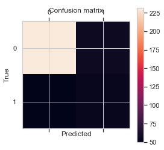

```python
cm = confusion_matrix(target_test, target_predicted_dt2)
plt.matshow(cm)
plt.title('Confusion matrix')
plt.colorbar()
plt.ylabel('True')
plt.xlabel('Predicted')
print(cm)
```

#### KNN

My first attempt will be ran with k =3:

```python
Titanic_knn = KNeighborsClassifier(n_neighbors=3)
Titanic_knn.fit(features_train, target_train)
target_predicted_knn = Titanic_knn.predict(features_test)

print(Titanic_knn)
```

```
KNeighborsClassifier(algorithm='auto', leaf_size=30, metric='minkowski',
           metric_params=None, n_jobs=None, n_neighbors=3, p=2,
           weights='uniform')
```

```python
print("KNN Accuracy Score", accuracy_score(target_test, target_predicted_knn))
print(classification_report(target_test, target_predicted_knn))
print(confusion_matrix(target_test, target_predicted_knn))
```

```
KNN Accuracy Score 0.7302798982188295
              precision    recall  f1-score   support

         0.0       0.81      0.83      0.82       289
         1.0       0.49      0.44      0.46       104

   micro avg       0.73      0.73      0.73       393
   macro avg       0.65      0.64      0.64       393
weighted avg       0.72      0.73      0.73       393

[[241  48]
 [ 58  46]]
```

```python
scores = cross_val_score(Titanic_knn, features_train, target_train, cv=10)
print("Cross Validation Score",scores)
scores.mean()
```

```
Cross Validation Score [0.63043478 0.65217391 0.64130435 0.75       0.73913043 0.68478261
 0.63043478 0.72826087 0.76666667 0.66666667]
```

```
0.6889855072463769
```

Not really an improvement from my decision tree model, as precision and recall are very low for my survivors. I'm going to adjust the k value higher:

```python
Titanic_knn2 = KNeighborsClassifier(n_neighbors=7)
Titanic_knn2.fit(features_train, target_train)
target_predicted_knn2 = Titanic_knn2.predict(features_test)

print(Titanic_knn2)
```

```
KNeighborsClassifier(algorithm='auto', leaf_size=30, metric='minkowski',
           metric_params=None, n_jobs=None, n_neighbors=7, p=2,
           weights='uniform')
```

```python
print("KNN Accuracy Score", accuracy_score(target_test, target_predicted_knn2))
print(classification_report(target_test, target_predicted_knn2))
print(confusion_matrix(target_test, target_predicted_knn2))
```

```
KNN Accuracy Score 0.732824427480916
              precision    recall  f1-score   support

         0.0       0.79      0.87      0.83       289
         1.0       0.49      0.35      0.41       104

   micro avg       0.73      0.73      0.73       393
   macro avg       0.64      0.61      0.62       393
weighted avg       0.71      0.73      0.72       393

[[252  37]
 [ 68  36]]
```

This may not be the best model for this data, based on the shortcomings I'm already experiencing with tuning

```
[[241  48]
 [ 58  46]]
```

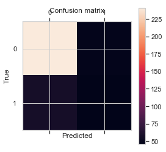

```python
cm = confusion_matrix(target_test, target_predicted_knn)
plt.matshow(cm)
plt.title('Confusion matrix')
plt.colorbar()
plt.ylabel('True')
plt.xlabel('Predicted')
print(cm)
```

#### Linear Regression (SVM)

```python
import os as os
from sklearn.linear_model import LinearRegression
from sklearn.metrics import mean_squared_error
%matplotlib inline
from sklearn.svm import LinearSVC
from sklearn.linear_model import Ridge
from sklearn.linear_model import Lasso
```

```python
linRidge=LinearSVC(penalty='l2', loss='squared_hinge', dual=True, tol=0.0001, C=1.0, class_weight='balanced')
linRidge.fit(features_train, target_train)
predicted_Ridge=linRidge.predict(features_test)
expected = target_test
```

```python
print(classification_report(expected, predicted_Ridge,target_names=['No survival', 'Survived']))
print(confusion_matrix(expected, predicted_Ridge))
print(accuracy_score(expected,predicted_Ridge))
```

```
              precision    recall  f1-score   support

 No survival       0.80      0.88      0.84       289
    Survived       0.55      0.40      0.46       104

   micro avg       0.75      0.75      0.75       393
   macro avg       0.67      0.64      0.65       393
weighted avg       0.74      0.75      0.74       393

[[254  35]
 [ 62  42]]
0.7531806615776081
```

```python
scores_linRidge = cross_val_score(linRidge, features_train, target_train, cv=10, n_jobs=-1)
print("Cross Validation Score",scores_linRidge)
scores_linRidge.mean()
```

[output not shown]

```
0.6860386473429951
```

I'm beginning to think there is a limitation in my preprocessing, because I expected my linear model to be a better predictor of survivors. I'm going to attempt an L1 penalty on this to see if I get different results - I'm mostly concerned with my cross validation scores, as it suggests there may be some underfitting.

```python
linLasso=LinearSVC(penalty='l1', loss='squared_hinge', dual=False, tol=0.0001, C=1.0, class_weight='balanced')
linLasso.fit(features_train, target_train)
predicted_Lasso=linLasso.predict(features_test)
expected = target_test

print(classification_report(expected, predicted_Lasso,target_names=['No survival', 'Survived']))
print(confusion_matrix(expected, predicted_Lasso))
print(accuracy_score(expected,predicted_Lasso))
```

```
              precision    recall  f1-score   support

 No survival       0.87      0.71      0.78       289
    Survived       0.47      0.70      0.56       104

   micro avg       0.71      0.71      0.71       393
   macro avg       0.67      0.71      0.67       393
weighted avg       0.76      0.71      0.72       393

[[206  83]
 [ 31  73]]
0.7099236641221374
```

```python
scores_linLasso = cross_val_score(linLasso, features_train, target_train, cv=10, n_jobs=-1)
print("Cross Validation Score",scores_linLasso)
scores_linLasso.mean()
```

```
Cross Validation Score [0.66304348 0.75       0.70652174 0.79347826 0.79347826 0.64130435
 0.67391304 0.7173913  0.76666667 0.74444444]
```

```
0.7250241545893721
```

My Lasso regression model is slightly better; my recall for survivors has spiked and my cv has more stability, but I would still like to see higher overall accuracy

```
[[206  83]
 [ 31  73]]
```

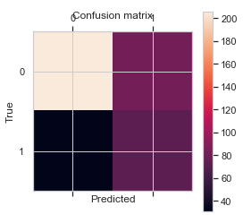

```python
cm = confusion_matrix(target_test, predicted_Lasso)
plt.matshow(cm)
plt.title('Confusion matrix')
plt.colorbar()
plt.ylabel('True')
plt.xlabel('Predicted')
print(cm)
```

Visualizing the variance of coefficients between standard linear regression, so I can see what my penalties are manipulating:

```python
model_LR = LinearRegression(normalize=True)
model_LR.fit(features_train, target_train)
```

```
LinearRegression(copy_X=True, fit_intercept=True, n_jobs=None, normalize=True)
```

```python
pd.DataFrame(np.transpose(model_LR.coef_))
```

|  | 0 |
| --- | --- |
| 0 | -4.040961e-03 |
| 1 | -4.903510e-04 |
| 2 | -1.688060e-02 |
| 3 | -3.533653e-01 |
| 4 | -1.891391e+13 |
| 5 | -1.891391e+13 |
| 6 | -1.891391e+13 |
| 7 | 3.618999e+13 |
| 8 | 3.618999e+13 |
| 9 | 3.618999e+13 |

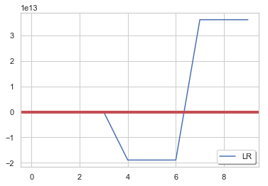

```python
fig, ax = plt.subplots()
plt.plot(model_LR.coef_, label='LR')
plt.axhline(linewidth=4, color='r') # for reference
legend = ax.legend(loc='lower right', shadow=True)
plt.show()
```

The variability of my coefficients serves as a confirmation that something is amiss in my preprocessing of the data

#### ANN

```python
from sklearn.preprocessing import StandardScaler
scaler = StandardScaler()

scaler.fit(features_train)
X_train = scaler.transform(features_train)

X_test = scaler.transform(features_test)
```

```python
from sklearn.neural_network import MLPClassifier

ANN = MLPClassifier(activation='relu', alpha=1e-05, batch_size='auto',
       beta_1=0.9, beta_2=0.999, early_stopping=False,
       epsilon=1e-08, hidden_layer_sizes=(10,8), learning_rate='constant',
       learning_rate_init=0.001, max_iter=200, momentum=0.9,
       nesterovs_momentum=True, power_t=0.5, random_state=1, shuffle=True,
       solver='lbfgs', tol=0.0001, validation_fraction=0.1, verbose=False,
       warm_start=False)
ANN.fit(features_train, target_train)

target_predicted_ANN = ANN.predict(features_test)
print("Accuracy", accuracy_score(target_test, target_predicted_ANN))
target_names = ["No survival", "Survived"]
print(classification_report(target_test, target_predicted_ANN, target_names=target_names))
print(confusion_matrix(target_test, target_predicted_ANN))
```

```
Accuracy 0.7786259541984732
              precision    recall  f1-score   support

 No survival       0.83      0.89      0.85       289
    Survived       0.60      0.48      0.53       104

   micro avg       0.78      0.78      0.78       393
   macro avg       0.71      0.68      0.69       393
weighted avg       0.77      0.78      0.77       393

[[256  33]
 [ 54  50]]
```

```python
scores_ANN= cross_val_score(ANN, features_train, target_train, cv=10, n_jobs=-1)
print("Cross Validation Score",scores_ANN)
scores_ANN.mean()
```

```
Cross Validation Score [0.73913043 0.7826087  0.82608696 0.81521739 0.81521739 0.72826087
 0.83695652 0.80434783 0.81111111 0.82222222]
```

```
0.7981159420289854
```

This model has better consistency with the cv, with some trials reaching over 80% accuracy. However, my scores for survivors is still faulty. I'm going to see if adding complexity with hidden layers and nodes will help my model perform:

```python
ANN2 = MLPClassifier(activation='relu', alpha=1e-05, batch_size='auto',
       beta_1=0.9, beta_2=0.999, early_stopping=False,
       epsilon=1e-08, hidden_layer_sizes=(30,20), learning_rate='constant',
       learning_rate_init=0.001, max_iter=200, momentum=0.9,
       nesterovs_momentum=True, power_t=0.5, random_state=1, shuffle=True,
       solver='lbfgs', tol=0.0001, validation_fraction=0.1, verbose=False,
       warm_start=False)
ANN2.fit(features_train, target_train)

target_predicted_ANN2 = ANN2.predict(features_test)
print("Accuracy", accuracy_score(target_test, target_predicted_ANN2))
target_names = ["No survival", "Survived"]
print(classification_report(target_test, target_predicted_ANN2, target_names=target_names))
print(confusion_matrix(target_test, target_predicted_ANN2))
```

```
Accuracy 0.7633587786259542
              precision    recall  f1-score   support

 No survival       0.80      0.90      0.85       289
    Survived       0.58      0.38      0.46       104

   micro avg       0.76      0.76      0.76       393
   macro avg       0.69      0.64      0.65       393
weighted avg       0.74      0.76      0.74       393

[[261  28]
 [ 65  39]]
```

It seems like adding complexity only hurts my model, so instead I'm going to go the opposite direction and introduce more bias with less hidden layers & nodes:

```python
ANN3 = MLPClassifier(activation='relu', alpha=1e-05, batch_size='auto',
       beta_1=0.9, beta_2=0.999, early_stopping=False,
       epsilon=1e-08, hidden_layer_sizes=(7,4), learning_rate='constant',
       learning_rate_init=0.001, max_iter=200, momentum=0.9,
       nesterovs_momentum=True, power_t=0.5, random_state=1, shuffle=True,
       solver='lbfgs', tol=0.0001, validation_fraction=0.1, verbose=False,
       warm_start=False)
ANN3.fit(features_train, target_train)

target_predicted_ANN3 = ANN3.predict(features_test)
print("Accuracy", accuracy_score(target_test, target_predicted_ANN3))
target_names = ["No survival", "Survived"]
print(classification_report(target_test, target_predicted_ANN3, target_names=target_names))
print(confusion_matrix(target_test, target_predicted_ANN3))
```

```
Accuracy 0.7760814249363868
              precision    recall  f1-score   support

 No survival       0.82      0.89      0.85       289
    Survived       0.60      0.45      0.52       104

   micro avg       0.78      0.78      0.78       393
   macro avg       0.71      0.67      0.69       393
weighted avg       0.76      0.78      0.76       393

[[258  31]
 [ 57  47]]
```

```python
scores_ANN3= cross_val_score(ANN3, features_train, target_train, cv=10, n_jobs=-1)
print("Cross Validation Score",scores_ANN3)
scores_ANN3.mean()
```

```
Cross Validation Score [0.72826087 0.7826087  0.82608696 0.81521739 0.81521739 0.7173913
 0.84782609 0.80434783 0.8        0.82222222]
```

```
0.7959178743961353
```

```
[[256  33]
 [ 54  50]]
```

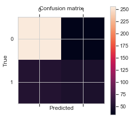

```python
cm = confusion_matrix(target_test, target_predicted_ANN) ## Using my first attempt since tuning didn't produce much alteration
plt.matshow(cm)
plt.title('Confusion matrix')
plt.colorbar()
plt.ylabel('True')
plt.xlabel('Predicted')
print(cm)
```

#### Logistic Regression

```python
from sklearn.linear_model import LogisticRegression
Titanic_Log=LogisticRegression()
print(Titanic_Log)
```

```
LogisticRegression(C=1.0, class_weight=None, dual=False, fit_intercept=True,
          intercept_scaling=1, max_iter=100, multi_class='warn',
          n_jobs=None, penalty='l2', random_state=None, solver='warn',
          tol=0.0001, verbose=0, warm_start=False)
```

```python
Titanic_Log = Titanic_Log.fit(features_train, target_train)

target_predicted_Log = Titanic_Log.predict(features_test)
print("Logistic Accuracy Score", accuracy_score(target_test, target_predicted_Log))

target_names = ["No Survival", "Survived"]
print(classification_report(target_test, target_predicted_Log, target_names=target_names))
```

```
Logistic Accuracy Score 0.7659033078880407
              precision    recall  f1-score   support

 No Survival       0.81      0.90      0.85       289
    Survived       0.58      0.40      0.48       104

   micro avg       0.77      0.77      0.77       393
   macro avg       0.70      0.65      0.66       393
weighted avg       0.75      0.77      0.75       393
```

```python
scores_Log= cross_val_score(Titanic_Log, features_train, target_train, cv=10, n_jobs=-1)
print("Cross Validation Score",scores_Log)
scores_Log.mean()
```

```
Cross Validation Score [0.73913043 0.79347826 0.82608696 0.81521739 0.79347826 0.69565217
 0.82608696 0.7826087  0.81111111 0.8       ]
```

```
0.7882850241545893
```

Like my linear regression model, I'm going to see if the Lasso method helps the performance here:

```python
Titanic_Log2 = LogisticRegression(penalty='l1')
print(Titanic_Log2)
```

```
LogisticRegression(C=1.0, class_weight=None, dual=False, fit_intercept=True,
          intercept_scaling=1, max_iter=100, multi_class='warn',
          n_jobs=None, penalty='l1', random_state=None, solver='warn',
          tol=0.0001, verbose=0, warm_start=False)
```

```python
Titanic_Log2 = Titanic_Log2.fit(features_train, target_train)

target_predicted_Log2 = Titanic_Log2.predict(features_test)
print("Logistic Accuracy Score", accuracy_score(target_test, target_predicted_Log2))

target_names = ["No Survival", "Survived"]
print(classification_report(target_test, target_predicted_Log2, target_names=target_names))
```

```
Logistic Accuracy Score 0.7684478371501272
              precision    recall  f1-score   support

 No Survival       0.81      0.90      0.85       289
    Survived       0.59      0.41      0.49       104

   micro avg       0.77      0.77      0.77       393
   macro avg       0.70      0.65      0.67       393
weighted avg       0.75      0.77      0.75       393
```

```python
scores_Log2= cross_val_score(Titanic_Log2, features_train, target_train, cv=10, n_jobs=-1)
print("Cross Validation Score",scores_Log2)
scores_Log2.mean()
```

```
Cross Validation Score [0.70652174 0.79347826 0.82608696 0.81521739 0.79347826 0.70652174
 0.83695652 0.7826087  0.81111111 0.8       ]
```

```
0.7871980676328503
```

There appears to be virtually no change between either of my attempts with logistic regression

```
[[259  30]
 [ 62  42]]
```

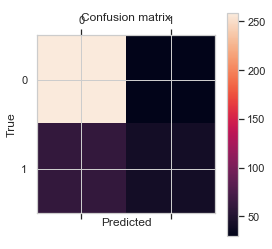

```python
cm = confusion_matrix(target_test, target_predicted_Log) ## Using my first attempt since tuning didn't produce much alteration
plt.matshow(cm)
plt.title('Confusion matrix')
plt.colorbar()
plt.ylabel('True')
plt.xlabel('Predicted')
print(cm)
```

#### Ensembling with Gradient Boosting; learning_rate = 0.1 and max_depth = None

```python
from sklearn.ensemble import GradientBoostingClassifier
Titanic_GBC = GradientBoostingClassifier(n_estimators=100, learning_rate=0.1, max_depth=None, random_state=0)
Titanic_GBC.fit(features_train, target_train)
predicted_GBC=Titanic_GBC.predict(features_test)
expected = target_test
print("Gradient Boost Accuracy", accuracy_score(expected,predicted_GBC))
print(classification_report(expected, predicted_GBC,target_names=['No survival', 'Survived']))
print(confusion_matrix(expected, predicted_GBC))
```

```
Gradient Boost Accuracy 0.7404580152671756
              precision    recall  f1-score   support

 No survival       0.84      0.81      0.82       289
    Survived       0.51      0.56      0.53       104

   micro avg       0.74      0.74      0.74       393
   macro avg       0.67      0.68      0.68       393
weighted avg       0.75      0.74      0.74       393

[[233  56]
 [ 46  58]]
```

```python
scores_GBC= cross_val_score(Titanic_GBC, features_train, target_train, cv=10, n_jobs=-1)
print("Cross Validation Score",scores_GBC)
scores_GBC.mean()
```

```
Cross Validation Score [0.7173913  0.72826087 0.69565217 0.81521739 0.7826087  0.67391304
 0.69565217 0.77173913 0.75555556 0.71111111]
```

```
0.7347101449275362
```